# EDA Final Project

### Problem Definition

Virat is a working professional in IT Sector planning to buy a smartwatch to track his daily fitness activities and stay connected through notifications and calls. While browsing multiple e-commerce platforms, he finds hundreds of smartwatches with overlapping features such as heart-rate monitoring, Bluetooth calling, AMOLED displays, and fitness tracking.

Despite having similar features:

- Some smartwatches are priced around ₹1,500 – ₹2,000
- Others are priced as high as ₹10,000 – ₹25,000+

### Business Questions

- Is paying a higher price for a smartwatch actually worth it?
- Do features like display type, Bluetooth calling, or fitness tracking significantly affect smartwatch prices?
- Are higher customer ratings associated with higher-priced smartwatches?
- Which smartwatch features genuinely increase the price?
- Which smartwatches provide the best value for money in different price ranges?

### Business Problem Statement

Smartwatch buyers face difficulty in choosing the right product due to too many options, inconsistent pricing, and unclear feature-to-price relationships. Many smartwatches offer similar specifications but differ significantly in price.

The goal of this project is to analyze smartwatch pricing and feature data using Exploratory Data Analysis (EDA) to uncover pricing patterns, identify important features influencing price, and help consumers make data-driven purchasing decisions.

### Project Objectives

The project follows a structured Data Analytics Life Cycle to ensure systematic analysis and meaningful insights.

- Business Problem & Understanding Understanding the smartwatch market, customer needs, and pricing challenges faced by buyers.
- Data Collection & Understanding Smartwatch data such as price, ratings, reviews, and product details is collected from Amazon using Selenium-based web scraping.
- Data Preprocessing (Cleaning) Cleaning the dataset by removing sponsored listings, handling missing values, and converting prices and review counts into numerical formats.
- Exploratory Data Analysis (EDA) Analyzing price distributions, comparing brands, and studying relationships between price, ratings, and reviews.
- Evaluation Evaluating whether higher prices are justified through customer ratings and popularity using analytical techniques.

## Data Preprocessing (Cleaning)

```python
import pandas as pd
import numpy as np
import matplotlib.pyplot as plt
import seaborn as sns

sns.set(style="whitegrid")
```

```python
df = pd.read_csv("final_raw_data.csv")
df.shape
```

```
(512, 17)
```

```python
df.columns
```

```
Index(['ASIN', 'Operating_System', 'Display_Size', 'Display_Type_Page',
       'Battery_Capacity', 'Battery_Info', 'Battery_Avg_Life', 'Wireless_Type',
       'Product_Name', 'Brand', 'Price', 'Reviews', 'Display_Type',
       'Has_Bluetooth_Calling', 'Has_SpO2', 'Target_Audience', 'Product_URL'],
      dtype='object')
```

```python
df["Price"] = df["Price"].round().astype("Int64")
```

```python
df["Price"].dtype
df["Price"].head()
```

```
0    1099
1    1099
2     999
3     999
4     349
Name: Price, dtype: Int64
```

```python
df["Price"].dtype
df["Price"].describe()
```

```
count           511.0
mean      4653.657534
std      10088.118481
min             174.0
25%            1244.0
50%            1999.0
75%            3299.0
max          157990.0
Name: Price, dtype: Float64
```

```python
def clean_reviews(value):
    if pd.isna(value):
        return None

    value = str(value).replace("(", "").replace(")", "").upper()

    if "K" in value:
        return float(value.replace("K", "")) * 1_000
    elif "L" in value:
        return float(value.replace("L", "")) * 100_000
    else:
        return float(value)
```

```python
df["Review_Count"] = df["Review_Count"].apply(clean_reviews)
```

```python
df["Review_Count"].describe()
```

```
count    510.000000
mean     128.843137
std      173.339030
min        1.000000
25%       21.250000
50%       61.000000
75%      172.000000
max      972.000000
Name: Review_Count, dtype: float64
```

```python
df["Display_Size"] = (
    df["Display_Size"]
    .astype(str)
    .str.replace("Inches", "", regex=False)
    .str.replace("Centimetres", "", regex=False)
    .str.strip()
)

df["Display_Size"] = pd.to_numeric(df["Display_Size"], errors="coerce")
```

```python
df["Display_Size"].describe()
```

```
count    432.000000
mean       2.113958
std        5.221758
min        0.500000
25%        1.430000
50%        1.500000
75%        1.850000
max       74.000000
Name: Display_Size, dtype: float64
```

```python
df["Battery_mAh"] = (
    df["Battery_mAh"]
    .astype(str)
    .str.extract(r"(\d+)", expand=False))

df["Battery_mAh"] = pd.to_numeric(df["Battery_mAh"], errors="coerce")
```

```python
df["Battery_mAh"].describe()
```

```
count     165.000000
mean      236.878788
std       404.514234
min         0.000000
25%         3.000000
50%       220.000000
75%       300.000000
max      5000.000000
Name: Battery_mAh, dtype: float64
```

```python
df["Battery_Life_Days"] = (
    df["Battery_Life_Days"]
    .astype(str)
    .str.extract(r"(\d+)", expand=False)
)

df["Battery_Life_Days"] = pd.to_numeric(df["Battery_Life_Days"], errors="coerce")
```

```python
df["Battery_Life_Days"].describe()
```

```
count    223.000000
mean       8.533632
std       28.986289
min        1.000000
25%        5.000000
50%        5.000000
75%        7.000000
max      432.000000
Name: Battery_Life_Days, dtype: float64
```

```python
df[[
    "Price",
    "Review_Count",
    "Display_Size",
    "Battery_mAh",
    "Battery_Life_Days"
]].head()
```

|  | Price | Review_Count | Display_Size | Battery_mAh | Battery_Life_Days |
| --- | --- | --- | --- | --- | --- |
| 0 | 1099.0 | 261.0 | 1.39 | 260.0 | NaN |
| 1 | 1099.0 | 261.0 | 1.39 | 260.0 | NaN |
| 2 | 999.0 | 12.0 | 1.83 | NaN | 7.0 |
| 3 | 999.0 | 12.0 | 1.83 | NaN | 7.0 |
| 4 | 349.0 | 12.0 | 1.33 | NaN | 1.0 |

```python
categorical_cols = [
    "Operating_System",
    "Display_Type",
    "Display_Type_Source",
    "Wireless_Type",
    "Brand",
    "Target_Audience"
]

for col in categorical_cols:
    df[col] = (
        df[col]
        .astype(str)
        .str.strip()
        .str.title()
        .replace("None", "Unknown"))
```

```python
df = df.drop_duplicates()
```

```python
df.shape
```

```
(512, 17)
```

### Checking Missing Values

```python
df.isnull().sum()
```

[output not shown]

### Handling Missing Values

```python
df["Display_Type"] = (
    df.groupby("Brand")["Display_Type"]
      .transform(lambda x: x.fillna(x.mode()[0] if not x.mode().empty else "Unknown")))
```

```python
df["Operating_System"] = (
    df.groupby("Brand")["Operating_System"]
      .transform(lambda x: x.fillna(x.mode()[0] if not x.mode().empty else "Unknown")))
```

```python
brand_display_median = (
    df.groupby("Brand")["Display_Size"].median())
```

```python
df["Display_Size"] = df["Display_Size"].fillna(
    df["Brand"].map(brand_display_median))
```

```python
global_display_median = df["Display_Size"].median()

df["Display_Size"] = df["Display_Size"].fillna(global_display_median)
```

```python
brand_battery_median = (
    df.groupby("Brand")["Battery_mAh"].median())

df["Battery_mAh"] = df["Battery_mAh"].fillna(
    df["Brand"].map(brand_battery_median))

global_battery_median = df["Battery_mAh"].median()

df["Battery_mAh"] = df["Battery_mAh"].fillna(global_battery_median)
```

```python
os_battery_life_median = (
    df.groupby("Operating_System")["Battery_Life_Days"].median())

df["Battery_Life_Days"] = df["Battery_Life_Days"].fillna(
    df["Operating_System"].map(os_battery_life_median))

global_battery_life_median = df["Battery_Life_Days"].median()
df["Battery_Life_Days"] = df["Battery_Life_Days"].fillna(global_battery_life_median)
```

```python
df.isnull().sum()
```

```
Brand                    0
Price                    1
Review_Count             2
Display_Size             0
Display_Type             0
Display_Type_Source      0
Operating_System         0
Battery_mAh              0
Battery_Life_Days        0
Battery_Info           147
Wireless_Type            0
Bluetooth_Calling        0
SpO2_Sensor              0
Target_Audience          0
dtype: int64
```

```python
df.groupby("Brand")["Battery_Info"].nunique().sort_values()
```

```
Brand
(Refurbished)    0
Acnos            0
Fitbit           0
Cellecor         0
Helix            0
Layers           0
Goqii            0
Matrix           0
Zovuta           0
Rkls             0
Spigen           0
Shocknshop       0
Techking         0
Strand           0
Punnk            0
Bouncefit        1
M                1
Just             1
Marvik           1
Giordano         1
Imoo             1
Itel             1
Google           1
Titan            1
Cultsport        1
Fire‑Boltt       1
Cult             1
Crossbeats       1
Fossil           1
Boult            1
Apple            1
Boltt            1
Oneplus          1
Vibez            1
Watchout         2
Nervfit          2
Redmi            2
Pebble           2
Goboult          2
Hammer           2
Fire-Boltt       2
Noisefit         2
Noise            2
Punnkfunnk       3
Boat             3
Amazfit          3
Huawei           3
Fastrack         3
Samsung          3
Garmin           4
Sekyo            4
Gamesir          5
Name: Battery_Info, dtype: int64
```

```python
brand_battery_type = (df.dropna(subset=["Battery_Info"])
    .groupby("Brand")["Battery_Info"].agg(lambda x: x.mode()[0] if len(x.mode()) == 1 else None))
```

```python
df["Battery_Info"] = df["Battery_Info"].fillna(df["Brand"].map(brand_battery_type))
```

```python
df["Battery_Info"].isnull().sum()
```

```
np.int64(35)
```

```python
eda_df.groupby("Brand")["Display_Type"].nunique().sort_values()
```

[output not shown]

```python
brand_display_map = (
    eda_df[eda_df["Display_Type"] != "Unknown"]
    .groupby("Brand")["Display_Type"]
    .agg(lambda x: x.mode()[0] if len(x.mode()) == 1 else None))
```

```python
eda_df["Display_Type"] = eda_df["Display_Type"].mask(
    eda_df["Display_Type"] == "Unknown",
    eda_df["Brand"].map(brand_display_map))
```

```python
eda_df["Display_Type"].value_counts()
```

```
Display_Type
Amoled     203
AMOLED     164
Digital      8
Lcd          7
Name: count, dtype: int64
```

### Boolean Normalization

```python
boolean_cols = [
    "Bluetooth_Calling",
    "SpO2_Sensor"
]

for col in boolean_cols:
    df[col] = (
        df[col].astype(str).str.lower().map({
            "true": 1,
            "false": 0,
            "yes": 1,
            "no": 0,
            "1": 1,
            "0": 0}))
```

```python
df[boolean_cols].dtypes
df[boolean_cols].value_counts()
```

```
Bluetooth_Calling  SpO2_Sensor
0                  0              239
1                  1              102
                   0               95
0                  1               76
Name: count, dtype: int64
```

### Rename Columns for Readability

```python
df = df.rename(columns={
    "Display_Type_Page": "Display_Type_Source",
    "Battery_Capacity": "Battery_mAh",
    "Battery_Avg_Life": "Battery_Life_Days",
    "Has_Bluetooth_Calling": "Bluetooth_Calling",
    "Has_SpO2": "SpO2_Sensor",
    "Reviews": "Review_Count"})
```

### Final Validation

```python
df.columns
```

```
Index(['ASIN', 'Operating_System', 'Display_Size', 'Display_Type_Source',
       'Battery_mAh', 'Battery_Info', 'Battery_Life_Days', 'Wireless_Type',
       'Product_Name', 'Brand', 'Price', 'Review_Count', 'Display_Type',
       'Bluetooth_Calling', 'SpO2_Sensor', 'Target_Audience', 'Product_URL'],
      dtype='object')
```

```python
eda_cols = [
    "Brand",
    "Price",
    "Review_Count",
    "Display_Size",
    "Display_Type",
    "Display_Type_Source",
    "Operating_System",
    "Battery_mAh",
    "Battery_Life_Days",
    "Battery_Info",
    "Wireless_Type",
    "Bluetooth_Calling",
    "SpO2_Sensor",
    "Target_Audience"]

eda_df = df[eda_cols].copy()
```

```python
eda_df.head()
eda_df.info()
```

[output not shown]

```python
eda_df.to_csv("eda_amazon_smartwatch_data.csv", index=False)
```

### Data Analysis

```python
import pandas as pd
import matplotlib.pyplot as plt
import seaborn as sns

sns.set(style="whitegrid")
plt.rcParams["figure.figsize"] = (8, 5)
```

```python
df = pd.read_csv("eda_amazon_smartwatch_data.csv")
df.shape
```

```
(512, 14)
```

```python
eda_df.shape
```

```
(512, 14)
```

```python
eda_df.info()
```

```
<class 'pandas.core.frame.DataFrame'>
RangeIndex: 512 entries, 0 to 511
Data columns (total 14 columns):
 #   Column               Non-Null Count  Dtype
---  ------               --------------  -----
 0   Brand                512 non-null    object
 1   Price                511 non-null    float64
 2   Review_Count         510 non-null    float64
 3   Display_Size         512 non-null    float64
 4   Display_Type         512 non-null    object
 5   Display_Type_Source  512 non-null    object
 6   Operating_System     512 non-null    object
 7   Battery_mAh          512 non-null    float64
 8   Battery_Life_Days    512 non-null    float64
 9   Battery_Info         477 non-null    object
 10  Wireless_Type        512 non-null    object
 11  Bluetooth_Calling    512 non-null    int64
 12  SpO2_Sensor          512 non-null    int64
 13  Target_Audience      512 non-null    object
dtypes: float64(5), int64(2), object(7)
memory usage: 56.1+ KB
```

### Descriptive Statistics

```python
eda_df.describe()
```

|  | Price | Review_Count | Display_Size | Battery_mAh | Battery_Life_Days | Bluetooth_Calling | SpO2_Sensor |
| --- | --- | --- | --- | --- | --- | --- | --- |
| count | 511.000000 | 510.000000 | 512.000000 | 512.000000 | 512.000000 | 512.000000 | 512.000000 |
| mean | 4653.657534 | 128.843137 | 2.031016 | 203.056641 | 8.429688 | 0.384766 | 0.347656 |
| std | 10088.118481 | 173.339030 | 4.800084 | 389.433070 | 20.780442 | 0.487016 | 0.476692 |
| min | 174.000000 | 1.000000 | 0.500000 | 0.000000 | 1.000000 | 0.000000 | 0.000000 |
| 25% | 1244.000000 | 21.250000 | 1.430000 | 15.000000 | 5.000000 | 0.000000 | 0.000000 |
| 50% | 1999.000000 | 61.000000 | 1.500000 | 210.000000 | 5.000000 | 0.000000 | 0.000000 |
| 75% | 3299.000000 | 172.000000 | 1.850000 | 210.000000 | 7.000000 | 1.000000 | 1.000000 |
| max | 157990.000000 | 972.000000 | 74.000000 | 5000.000000 | 432.000000 | 1.000000 | 1.000000 |

#### Categorical Features

```python
eda_df["Brand"].value_counts().head(10)
```

```
Brand
Boat          73
Fire-Boltt    65
Noise         61
Fastrack      58
Punnkfunnk    23
Gamesir       23
Noisefit      21
Pebble        17
Garmin        12
Samsung       11
Name: count, dtype: int64
```

```python
eda_df["Display_Type"].value_counts()
```

```
Display_Type
Amoled     203
AMOLED     164
Digital      8
Lcd          7
Name: count, dtype: int64
```

```python
brand_counts = eda_df["Brand"].value_counts()
brand_percent = (brand_counts / len(eda_df)) * 100

brand_summary = pd.DataFrame({
    "Count": brand_counts,
    "Percentage (%)": brand_percent.round(2)})

brand_summary.head(10)
```

| Brand | Count | Percentage (%) |
| --- | --- | --- |
| Boat | 73 | 14.26 |
| Fire-Boltt | 65 | 12.70 |
| Noise | 61 | 11.91 |
| Fastrack | 58 | 11.33 |
| Punnkfunnk | 23 | 4.49 |
| Gamesir | 23 | 4.49 |
| Noisefit | 21 | 4.10 |
| Pebble | 17 | 3.32 |
| Garmin | 12 | 2.34 |
| Samsung | 11 | 2.15 |

```python
eda_df["Target_Audience"].value_counts()
```

```
Target_Audience
Unisex    248
Women     182
Kids       61
Men        21
Name: count, dtype: int64
```

```python
def normalize_os(os):
    if pd.isna(os):
        return "Unknown"

    os = os.lower()

    if "android wear" in os or "wear os" in os:
        return "Wear OS"
    elif "android" in os:
        return "Android"
    elif "watchos" in os or "ios" in os:
        return "WatchOS"
    elif "zepp" in os:
        return "Zepp OS"
    elif "pebble" in os:
        return "Pebble OS"
    else:
        return "Proprietary / Other"
```

```python
eda_df["OS_Normalized"] = eda_df["Operating_System"].apply(normalize_os)
```

### Univariate Analysis

#### Price Distribution

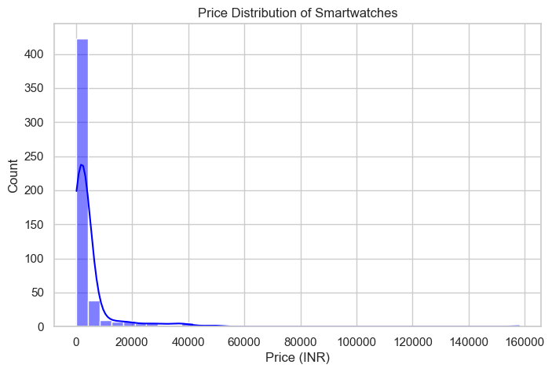

```python
sns.histplot(eda_df["Price"].dropna(), bins=30, kde=True,color="blue")
plt.title("Price Distribution of Smartwatches")
plt.xlabel("Price (INR)")
plt.ylabel("Count")
plt.show()
```

**Observations:**

- The price distribution is right-skewed, indicating that most smartwatches fall in the budget to mid-range category.
- A small number of premium smartwatches form the higher end of the price spectrum.
- This suggests that affordability is a major focus in the Indian smartwatch market.

**Business Insight:**

- Brands primarily compete on price in the lower segments, while premium products target a niche audience.

#### Reviews Distribution

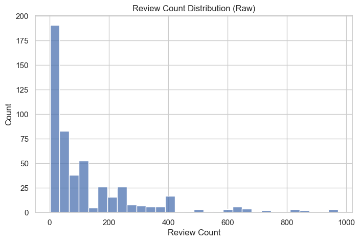

```python
sns.histplot(
    eda_df["Review_Count"].dropna(),
    bins=30,
    kde=False)

plt.title("Review Count Distribution (Raw)")
plt.xlabel("Review Count")
plt.ylabel("Count")
plt.show()
```

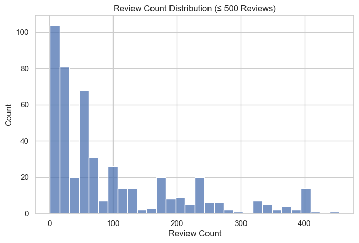

```python
sns.histplot(
    eda_df.loc[eda_df["Review_Count"] <= 500, "Review_Count"],
    bins=30,
    kde=False)

plt.title("Review Count Distribution (≤ 500 Reviews)")
plt.xlabel("Review Count")
plt.ylabel("Count")
plt.show()
```

**Observations:**

- Review counts are heavily right-skewed.
- Most smartwatches have low to moderate reviews (0–100).
- Only a small number of products accumulate very high review counts.

**Business Insight:**

- High review counts indicate mass adoption, not premium pricing.
- Budget and mid-range smartwatches dominate sales volume, while premium watches sell fewer units.
- Review count reflects popularity and reach, not product value or price justification.

#### Brand Distribution

```python
brand_counts = eda_df["Brand"].value_counts()
brand_percent = (brand_counts / len(eda_df)) * 100

brand_summary = pd.DataFrame({
    "Count": brand_counts,
    "Percentage (%)": brand_percent.round(2)})

brand_summary.head(10)
```

| Brand | Count | Percentage (%) |
| --- | --- | --- |
| Boat | 73 | 14.26 |
| Fire-Boltt | 65 | 12.70 |
| Noise | 61 | 11.91 |
| Fastrack | 58 | 11.33 |
| Punnkfunnk | 23 | 4.49 |
| Gamesir | 23 | 4.49 |
| Noisefit | 21 | 4.10 |
| Pebble | 17 | 3.32 |
| Garmin | 12 | 2.34 |
| Samsung | 11 | 2.15 |

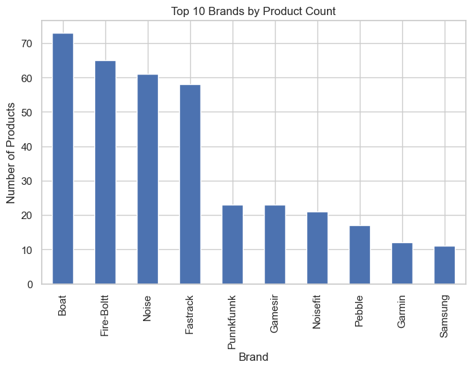

```python
brand_summary.head(10)["Count"].plot(kind="bar")
plt.title("Top 10 Brands by Product Count")
plt.xlabel("Brand")
plt.ylabel("Number of Products")
plt.show()
```

**Observations:**

- boAt, Fire-Boltt, Noise, and Fastrack have the highest number of smartwatch listings.
- There is a sharp drop in product count after the top 4 brands.
- Premium brands like Garmin and Samsung have comparatively fewer models.
- Competition is intense among leading brands.

**Business Insight:**

- The smartwatch market is highly concentrated, dominated by a few mass-market brands.
- Leading brands focus on volume and frequent launches, while premium brands prioritize selective, high-value retail.
- Product count reflects market penetration strategy, not necessarily product quality.

### Display Type Distribution

```python
display_counts = eda_df["Display_Type"].value_counts()
display_counts
```

```
Display_Type
Amoled     203
AMOLED     164
Digital      8
Lcd          7
Name: count, dtype: int64
```

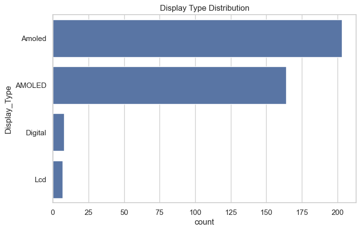

```python
sns.countplot(
    y="Display_Type",
    data=eda_df,
    order=display_counts.index)
plt.title("Display Type Distribution")
plt.show()
```

**Observations:**

- AMOLED displays dominate the smartwatch market by a large margin.
- LCD and Digital displays appear in very limited numbers.

**Business Insight:**

- AMOLED has become the industry standard for smartwatches due to better display quality and user experience.
- LCD and Digital displays are now mostly restricted to entry-level or niche models.
- Display technology adoption reflects market maturity and consumer expectations rather than premium positioning alone.

### Operating System Distribution

```python
os_counts = eda_df["OS_Normalized"].value_counts()
os_percent = (os_counts / len(eda_df)) * 100

os_summary = pd.DataFrame({
    "Count": os_counts,
    "Percentage (%)": os_percent.round(2)})
os_summary
```

| OS_Normalized | Count | Percentage (%) |
| --- | --- | --- |
| Android | 264 | 51.56 |
| Proprietary / Other | 152 | 29.69 |
| Wear OS | 53 | 10.35 |
| WatchOS | 25 | 4.88 |
| Pebble OS | 10 | 1.95 |
| Zepp OS | 8 | 1.56 |

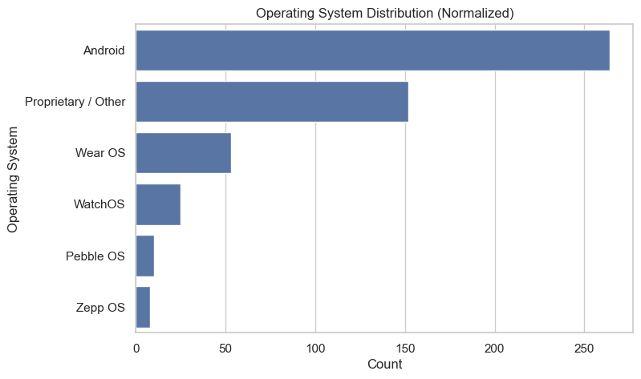

```python
sns.countplot(
    y="OS_Normalized",
    data=eda_df,
    order=eda_df["OS_Normalized"].value_counts().index)
plt.title("Operating System Distribution (Normalized)")
plt.xlabel("Count")
plt.ylabel("Operating System")
plt.show()
```

### Battery Life Distribution

```python
eda_df["Battery_Life_Days"].describe()
```

```
count    512.000000
mean       8.429688
std       20.780442
min        1.000000
25%        5.000000
50%        5.000000
75%        7.000000
max      432.000000
Name: Battery_Life_Days, dtype: float64
```

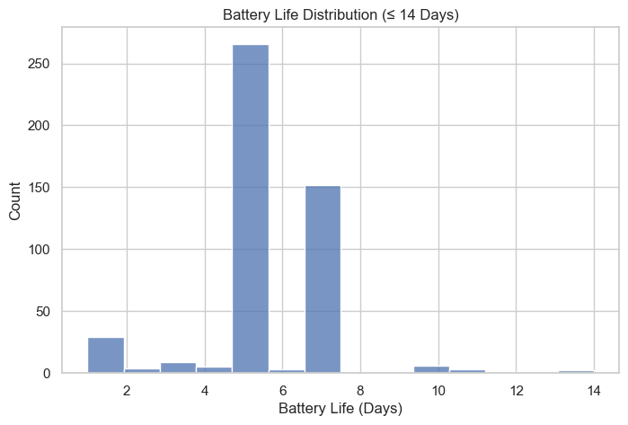

```python
sns.histplot(
    eda_df[eda_df["Battery_Life_Days"] <= 14]["Battery_Life_Days"],
    bins=14,
    kde=False)
plt.title("Battery Life Distribution (≤ 14 Days)")
plt.xlabel("Battery Life (Days)")
plt.show()
```

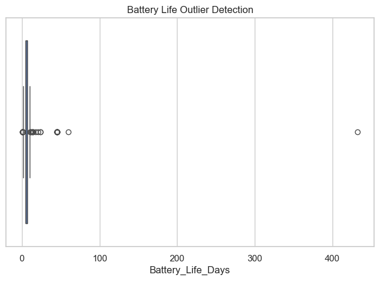

```python
sns.boxplot(x=eda_df["Battery_Life_Days"])
plt.title("Battery Life Outlier Detection")
plt.show()
```

**Insight**

> Battery life shows strong right skewness due to a small number of listings reporting unusually high values. For interpretability, histogram analysis focuses on realistic usage ranges, while boxplots are used to highlight outliers.

#### Target Audience Distribution

```python
audience_counts = eda_df["Target_Audience"].value_counts()
audience_counts
```

```
Target_Audience
Unisex    248
Women     182
Kids       61
Men        21
Name: count, dtype: int64
```

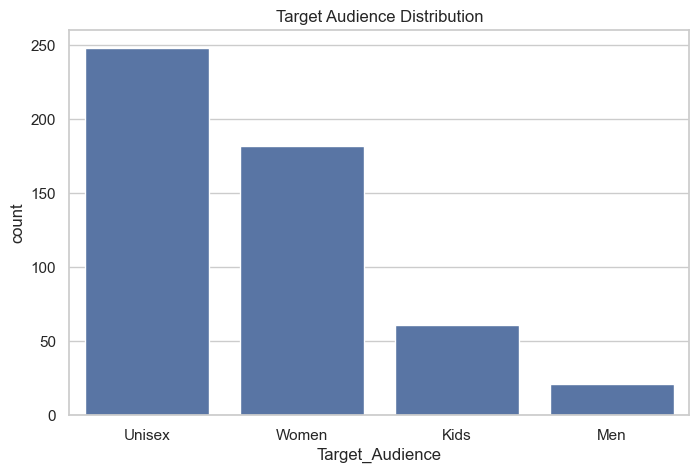

```python
sns.countplot(
    x="Target_Audience",
    data=eda_df,
    order=audience_counts.index)
plt.title("Target Audience Distribution")
plt.show()
```

## Bivariate Analysis

#### Brand-wise Average Price

```python
top_brands = eda_df["Brand"].value_counts().head(8).index
```

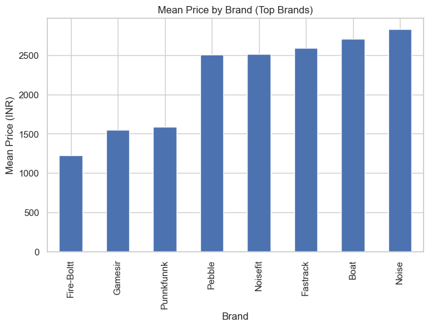

```python
mean_price_brand = (
    eda_df[eda_df["Brand"].isin(top_brands)]
    .groupby("Brand")["Price"]
    .mean()
    .sort_values()
)

mean_price_brand.plot(kind="bar")
plt.title("Mean Price by Brand (Top Brands)")
plt.xlabel("Brand")
plt.ylabel("Mean Price (INR)")
plt.show()
```

### Price vs Reviews (Value for Money)

```python
price_bins = [0, 1000, 3000, 5000, 10000, 20000, 200000]
price_labels = [
    "≤1K",
    "1K–3K",
    "3K–5K",
    "5K–10K",
    "10K–20K",
    ">20K"]
eda_df["Price_Bucket"] = pd.cut(
    eda_df["Price"],
    bins=price_bins,
    labels=price_labels)
```

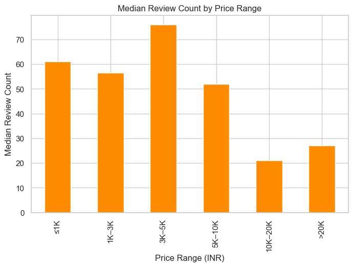

```python
median_reviews_by_price = (
    eda_df
    .groupby("Price_Bucket")["Review_Count"]
    .median()
)

median_reviews_by_price.plot(kind="bar",color='darkorange')
plt.title("Median Review Count by Price Range")
plt.xlabel("Price Range (INR)")
plt.ylabel("Median Review Count")
plt.show()
```

**Insight**

> Reviews are higher for budget and mid-range smartwatches, while premium devices receive fewer reviews. This suggests that customer engagement is driven more by affordability and mass-market adoption than by higher pricing.

### PRICE vs DISPLAY TYPE

```python
eda_df["Display_Type"] = (
    eda_df["Display_Type"]
    .str.strip()
    .str.lower()
)
```

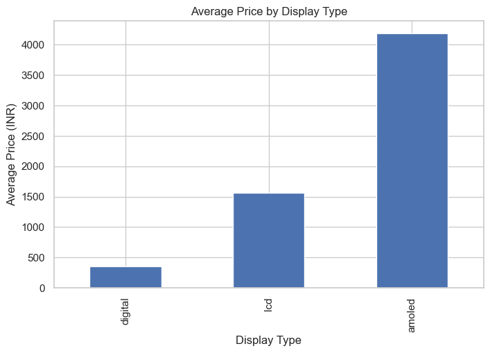

```python
display_df = eda_df[["Display_Type", "Price"]].dropna()

median_price_by_display = (
    display_df
    .groupby("Display_Type")["Price"]
    .mean()
    .sort_values()
)

median_price_by_display.plot(kind="bar")
plt.title("Average Price by Display Type")
plt.xlabel("Display Type")
plt.ylabel("Average Price (INR)")
plt.show()
```

**Observations:**

AMOLED smartwatches have a higher price compared to non-AMOLED models.

LCD and digital display types are generally priced lower.

**Business Insight:**

Display technology significantly impacts smartwatch pricing.

#### PRICE vs BLUETOOTH CALLING

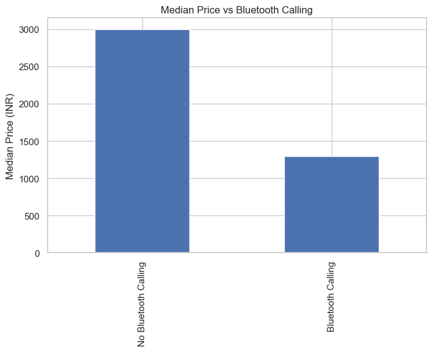

```python
median_price_bt = (
    eda_df
    .groupby("Bluetooth_Calling")["Price"]
    .median())

median_price_bt.index = ["No Bluetooth Calling", "Bluetooth Calling"]

median_price_bt.plot(kind="bar")
plt.title("Median Price vs Bluetooth Calling")
plt.ylabel("Median Price (INR)")
plt.show()
```

#### PRICE vs BATTERY LIFE

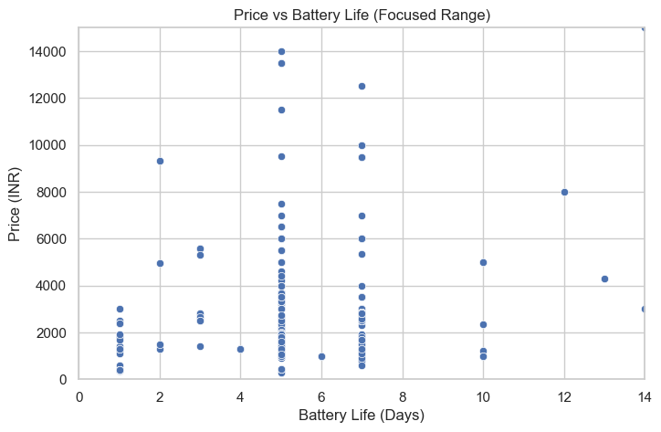

```python
sns.scatterplot(
    x="Battery_Life_Days",
    y="Price",
    data=eda_df
)

plt.xlim(0, 14)      # realistic everyday usage range
plt.ylim(0, 15000)  # mass-market price range

plt.title("Price vs Battery Life (Focused Range)")
plt.xlabel("Battery Life (Days)")
plt.ylabel("Price (INR)")
plt.show()
```

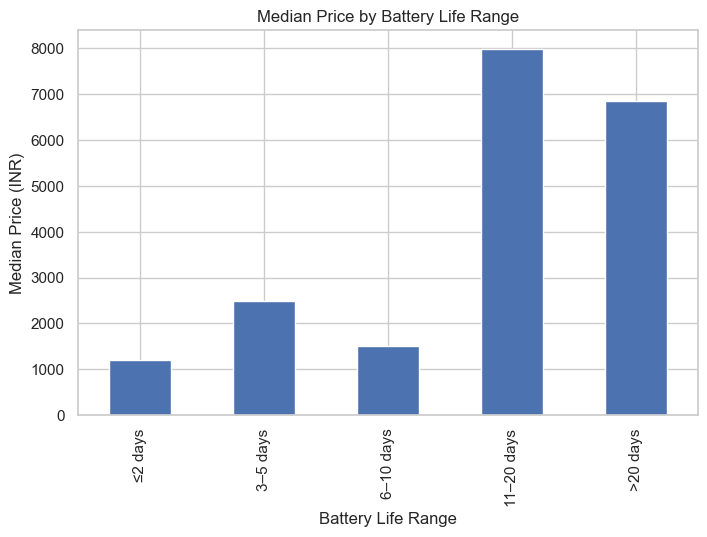

```python
battery_bins = [0, 2, 5, 10, 20, 100]
battery_labels = ["≤2 days", "3–5 days", "6–10 days", "11–20 days", ">20 days"]

eda_df["Battery_Life_Bucket"] = pd.cut(
    eda_df["Battery_Life_Days"],
    bins=battery_bins,
    labels=battery_labels
)

median_price_battery = (
    eda_df
    .groupby("Battery_Life_Bucket")["Price"]
    .median()
)

median_price_battery.plot(kind="bar")
plt.title("Median Price by Battery Life Range")
plt.xlabel("Battery Life Range")
plt.ylabel("Median Price (INR)")
plt.show()
```

**Insight**

#### Correlation Matrix (Numerical Features)

```python
numeric_cols_clean = [
    "Price",
    "Battery_mAh",
    "Review_Count"]

corr_df_clean = eda_df[numeric_cols_clean]
```

```python
corr_matrix_clean = corr_df_clean.corr()
corr_matrix_clean
```

|  | Price | Battery_mAh | Review_Count |
| --- | --- | --- | --- |
| Price | 1.000000 | 0.040858 | -0.017392 |
| Battery_mAh | 0.040858 | 1.000000 | 0.072056 |
| Review_Count | -0.017392 | 0.072056 | 1.000000 |

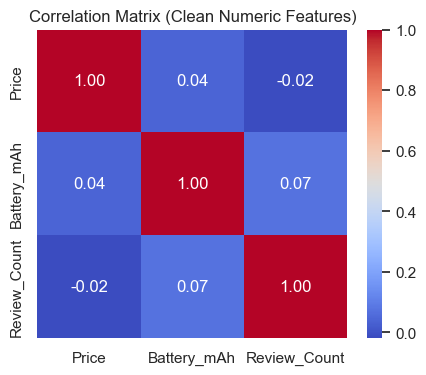

```python
plt.figure(figsize=(5, 4))
sns.heatmap(
    corr_matrix_clean,
    annot=True,
    cmap="coolwarm",
    fmt=".2f")
plt.title("Correlation Matrix (Clean Numeric Features)")
plt.show()
```

**Insights**

> Correlation analysis on cleaned numeric features shows no strong linear relationship between price, battery capacity, or review count. This confirms that smartwatch pricing is influenced more by brand positioning and feature combinations rather than isolated numeric specifications.

### Brand-Level Analysis

#### Average Price by Brand

```python
brand_price = (
    eda_df.groupby("Brand")["Price"]
    .mean()
    .sort_values(ascending=False)
)

brand_price.head(10)
```

```
Brand
Apple            42566.666667
Garmin           41865.000000
Google           26990.000000
Samsung          25432.909091
Amazfit          18387.888889
Fitbit           15671.222222
(Refurbished)    12824.000000
Huawei           10249.000000
Imoo              9490.000000
Oneplus           7823.666667
Name: Price, dtype: float64
```

#### Average Reviews by Brand

```python
eda_df.groupby("Brand")["Review_Count"].mean().sort_values(ascending=False).head(10)
```

```
Brand
Cultsport     645.000000
Shocknshop    641.000000
Boult         417.000000
Cult          364.000000
Fire‑Boltt    343.857143
Boltt         334.000000
Spigen        307.400000
Layers        258.000000
Goboult       250.090909
Hammer        242.857143
Name: Review_Count, dtype: float64
```

## Hypothesis Testing

#### EVALUATION (HYPOTHESIS TESTING) – SMARTWATCH PROJECT

```python
# Keep only valid numeric prices
df_test = eda_df.copy()

df_test = df_test[
    (df_test["Price"].notna()) &
    (df_test["Price"] > 0)
]
```

#### Hypothesis 1: Bluetooth Calling vs Price

**EDA Observation**

- Smartwatches without Bluetooth calling showed a higher median price, driven by premium brands.

**Hypotheses**

- H₀: Price distributions are the same for watches with and without Bluetooth calling
- H₁: Price distributions differ significantly based on Bluetooth calling
- Statistical Test
- Mann–Whitney U test (Used because price is skewed with outliers)

```python
from scipy.stats import mannwhitneyu

price_bt = df_test[df_test["Bluetooth_Calling"] == 1]["Price"]
price_no_bt = df_test[df_test["Bluetooth_Calling"] == 0]["Price"]

stat, p_value = mannwhitneyu(
    price_bt,
    price_no_bt,
    alternative="two-sided")

stat, p_value
```

```
(np.float64(15349.0), np.float64(7.932239627284475e-22))
```

**Result & Interpretation**

- Since p-value < 0.05, we reject the null hypothesis.
- There is a statistically significant difference in smartwatch prices based on Bluetooth calling availability.

**Business Insight**

- Bluetooth calling is common in mid-range mass-market devices, while premium brands often prioritize build quality, ecosystem, and brand value over this feature.

### Hypothesis 2: Battery Life vs Price

**EDA Observation**

- Battery life did not show a clear monotonic relationship with price.

**Hypotheses**

- H₀: Battery life and price are not related
- H₁: Battery life and price are related

*Statistical Test*

*Spearman correlation* (Non-linear, ordinal relationship)

```python
from scipy.stats import spearmanr

corr, p_value = spearmanr(
    df_test["Battery_Life_Days"],
    df_test["Price"],
    nan_policy="omit")

corr, p_value
```

```
(np.float64(0.03825805823892623), np.float64(0.38811916462679263))
```

**Result & Interpretation**

- Battery life alone does not justify higher pricing in smartwatches. Premium pricing is more strongly influenced by brand, ecosystem integration, and software capabilities rather than raw battery duration.

### **FINAL BUSINESS INSIGHTS**

**Price Distribution Analysis** What I Observed

- Smartwatch prices are strongly right-skewed.
- A small number of premium and luxury watches (₹30,000–₹1,50,000+) significantly pull the average price upward.
- Median prices are much lower than mean prices, indicating that most products lie in the affordable range.

**Interpretation**

- The smartwatch market is dominated by budget and mid-range devices.
- Mean price is misleading due to the presence of premium brands such as Apple, Garmin, and Samsung.
- Median price better represents what a typical buyer actually pays.

**Business Insight**

- Paying very high prices for a smartwatch is not the norm.Buyers should focus on median price ranges, not premium extremes that inflate averages without proportional everyday value.

**Bluetooth Calling vs Price** What I Observed

- Watches without Bluetooth calling show a higher median price than those with Bluetooth calling.
- Hypothesis testing (Mann–Whitney U test) confirms this difference is statistically significant (p ≪ 0.05).

**Interpretation**

- Bluetooth calling is more common in mid-range mass-market devices.
- Premium watches prioritize ecosystem integration, build quality, software, and brand positioning over Bluetooth calling.

**Business Insight**

- Bluetooth calling is not a premium feature.Buyers should not assume that the presence of Bluetooth calling implies a higher-end or better smartwatch.

**Battery Life vs Price**

- Battery life does not show a clear monotonic relationship with price.
- Spearman correlation is near zero and not statistically significant.

**Interpretation**

- Higher price does not guarantee longer battery life.
- Premium watches often trade battery duration for advanced features, displays, and OS capabilities.

**Business Insight**

- Buyers should not overpay expecting better battery life.
- Battery performance depends more on OS optimization and usage patterns than price alone.

**Price vs Reviews (Popularity Effect)**

**Interpretation**

- Review volume reflects sales volume and accessibility, not product value.
- Budget and mid-range watches attract more buyers and therefore more reviews.

**Business Insight**

- A smartwatch with fewer reviews is not necessarily inferior.

**Brand-Level Pricing Differences**

- Certain brands consistently occupy higher price ranges.
- Budget brands dominate the lower and mid-price segments, while a few brands form a premium cluster.

**Interpretation**

- Brand positioning is a stronger price driver than individual features.
- Pricing reflects ecosystem strength, trust, and long-term support, not just hardware specs.

**Business Insight**

- Buyers should evaluate whether they are paying for brand value or actual feature utility.
- For feature-focused buyers, mid-range brands often offer better value for money.

**Outliers & Market Segmentation**

- High-price outliers are real products, not data errors.
- These represent a luxury smartwatch segment.

**Interpretation**

- The smartwatch market is segmented into:

> Budget

> > Mid-range

> > > Premium

> > > > Luxury
- Outliers provide insight into market positioning, not noise.

**Business Insight**

- Luxury smartwatches exist, but they are not value-optimized for most users.
- Buyers should avoid expensive models unless they clearly benefit from brand ecosystem or specialized use cases.

**FINAL BUSINESS INSIGHTS (Answering Buyer’s Questions)**

- Is paying more for a smartwatch really worth it?

> Mostly NO. Beyond a certain price point, gains are marginal and driven by brand and ecosystem rather than utility.
- Does Bluetooth calling justify higher price?

> NO. It is more common in mid-range watches than premium ones.
- Does longer battery life mean higher price?

> NO. Battery life and price are largely independent.
- Do more reviews mean better quality?

> NO. Reviews reflect popularity, not premium value.
- What matters most for pricing?

> Brand positioning and ecosystem, not individual features.

**FINAL RECOMMENDATIONS**

- For value-conscious smartwatch buyers:
- Focus on mid-range price segments
- Do not overpay for Bluetooth calling
- Ignore luxury price outliers unless ecosystem matters
- Choose battery life based on usage needs, not price
- Evaluate brands carefully rather than chasing feature counts

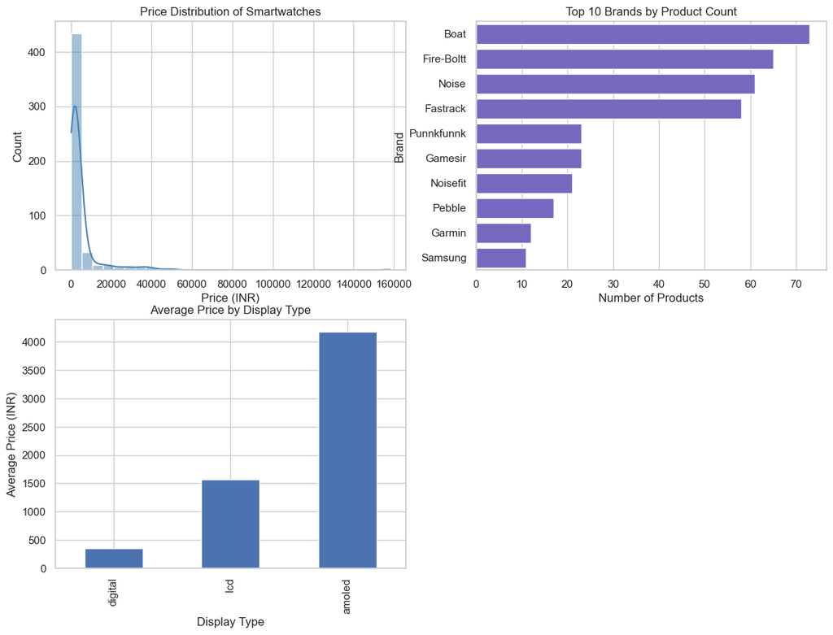

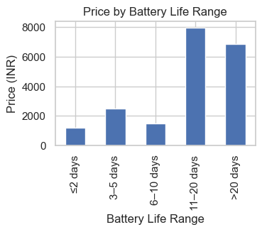

```python
import matplotlib.pyplot as plt
import seaborn as sns

plt.figure(figsize=(14, 10))

# 1️⃣ Price Distribution
plt.subplot(2, 2, 1)
sns.histplot(
    eda_df["Price"].dropna(),
    bins=30,
    kde=True,
    color="steelblue"
)
plt.title("Price Distribution of Smartwatches")
plt.xlabel("Price (INR)")
plt.ylabel("Count")

# 2️⃣ Top 10 Brands by Product Count
plt.subplot(2, 2, 2)
brand_counts = eda_df["Brand"].value_counts().head(10)
sns.barplot(
    x=brand_counts.values,
    y=brand_counts.index,
    color="slateblue"
)
plt.title("Top 10 Brands by Product Count")
plt.xlabel("Number of Products")
plt.ylabel("Brand")

# 3️⃣ PRICE vs DISPLAY TYPE
plt.subplot(2, 2, 3)
median_price_by_display = (
    display_df
    .groupby("Display_Type")["Price"]
    .mean()
    .sort_values()
)

median_price_by_display.plot(kind="bar")
plt.title("Average Price by Display Type")
plt.xlabel("Display Type")
plt.ylabel("Average Price (INR)")
plt.show()

# 4️⃣ Battery Life vs Price (Focused Scatter)
plt.subplot(2, 2, 4)
battery_bins = [0, 2, 5, 10, 20, 100]
battery_labels = ["≤2 days", "3–5 days", "6–10 days", "11–20 days", ">20 days"]

eda_df["Battery_Life_Bucket"] = pd.cut(
    eda_df["Battery_Life_Days"],
    bins=battery_bins,
    labels=battery_labels
)

median_price_battery = (
    eda_df
    .groupby("Battery_Life_Bucket")["Price"]
    .median()
)

median_price_battery.plot(kind="bar")
plt.title("Price by Battery Life Range")
plt.xlabel("Battery Life Range")
plt.ylabel("Price (INR)")
plt.show()
```

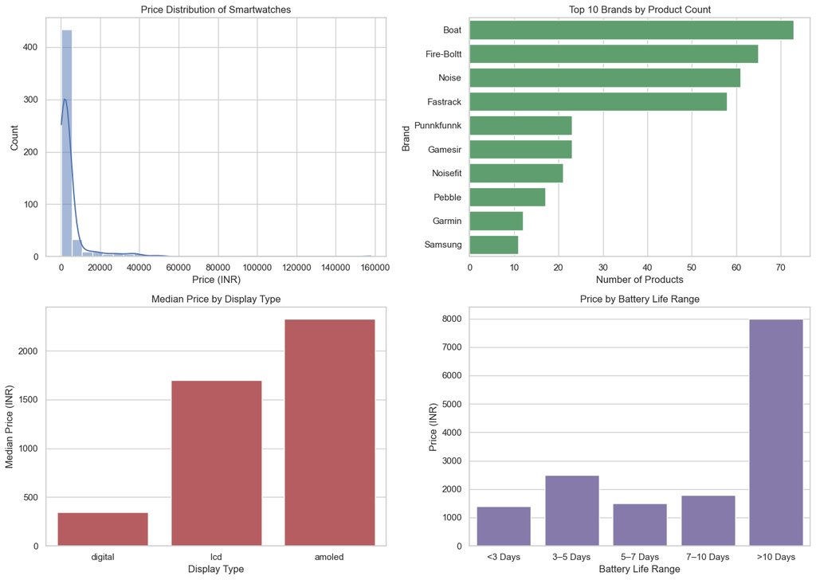

```python
import matplotlib.pyplot as plt
import seaborn as sns

plt.figure(figsize=(14, 10))

# -------------------- Plot 1: Price Distribution --------------------
plt.subplot(2, 2, 1)
sns.histplot(
    eda_df["Price"].dropna(),
    bins=30,
    kde=True,
    color="#4C72B0"
)
plt.title("Price Distribution of Smartwatches")
plt.xlabel("Price (INR)")
plt.ylabel("Count")

# -------------------- Plot 2: Top 10 Brands --------------------
plt.subplot(2, 2, 2)
top_brands = eda_df["Brand"].value_counts().head(10)
sns.barplot(
    x=top_brands.values,
    y=top_brands.index,
    color="#55A868"
)
plt.title("Top 10 Brands by Product Count")
plt.xlabel("Number of Products")
plt.ylabel("Brand")

# -------------------- Plot 3: Median Price by Display Type --------------------
plt.subplot(2, 2, 3)
display_median = (
    eda_df
    .groupby("Display_Type")["Price"]
    .median()
    .sort_values()
)
sns.barplot(
    x=display_median.index,
    y=display_median.values,
    color="#C44E52"
)
plt.title("Median Price by Display Type")
plt.xlabel("Display Type")
plt.ylabel("Median Price (INR)")

# -------------------- Plot 4: Median Price by Battery Life Range --------------------
plt.subplot(2, 2, 4)
battery_bins = [0, 3, 5, 7, 10, 20]
battery_labels = ["<3 Days", "3–5 Days", "5–7 Days", "7–10 Days", ">10 Days"]

eda_df["Battery_Life_Range"] = pd.cut(
    eda_df["Battery_Life_Days"],
    bins=battery_bins,
    labels=battery_labels
)

battery_price = (
    eda_df
    .groupby("Battery_Life_Range")["Price"]
    .median()
)

sns.barplot(
    x=battery_price.index,
    y=battery_price.values,
    color="#8172B2"
)
plt.title("Price by Battery Life Range")
plt.xlabel("Battery Life Range")
plt.ylabel("Price (INR)")

plt.tight_layout()
plt.show()
```